# Lab 1: NYT API

Andrew Bartnik

2023-04-05

```r
#create the query url
url <- paste("http://api.nytimes.com/svc/search/v2/articlesearch.json?q=haaland&api-key=",API_KEY, sep ="")
#send the request, receive the response, and flatten
t <- fromJSON(url, flatten = T)
```

## Assignment (Due Tuesday 4/11 11:59pm)

1. Create a free New York Times account (https://developer.nytimes.com/get-started)
2. Pick an interesting environmental key word(s) and use the {jsonlite} package to query the API. Pick something high profile enough and over a large enough time frame that your query yields enough articles for an interesting examination.

```r
term2 <- "biodiversity" # Need to use $ to string  together separate terms
begin_date2 <- "20210120"
end_date2 <- "20230401"
#construct the query url using API operators
baseurl2 <- paste0("http://api.nytimes.com/svc/search/v2/articlesearch.json?q=",term2,"&begin_date=",begin_date2,"&end_date=",end_date2,"&facet_filter=true&api-key=","NTKBHbsb6XFEkGymGumAiba7n3uBvs8V", sep="")
#examine our query url
baseurl2
```

```
## [1] "http://api.nytimes.com/svc/search/v2/articlesearch.json?q=biodiversity&begin_date=20210120&end_date=20230401&facet_filter=true&api-key=NTKBHbsb6XFEkGymGumAiba7n3uBvs8V"
```

```r
#dig into the JSON object to find total hits
initialQuery2 <- fromJSON(baseurl2)
maxPages <- round((initialQuery2$response$meta$hits[1] / 20)-1)
#initiate a list to hold results of our for loop
pages2 <- list()
#loop
for(i in 0:maxPages){
  nytSearch2 <- fromJSON(paste0(baseurl2, "&page=", i), flatten = TRUE) %>% data.frame()
  message("Retrieving page ", i)
  pages2[[i+1]] <- nytSearch2
  Sys.sleep(60)
  }
```

```
## Retrieving page 0
```

```
## Retrieving page 1
```

```
## Retrieving page 2
```

```
## Retrieving page 3
```

```
## Retrieving page 4
```

```
## Retrieving page 5
```

```
## Retrieving page 6
```

```
## Retrieving page 7
```

```
## Retrieving page 8
```

```
## Retrieving page 9
```

```
## Retrieving page 10
```

```
## Retrieving page 11
```

```
## Retrieving page 12
```

```
## Retrieving page 13
```

```
## Retrieving page 14
```

```
## Retrieving page 15
```

```
## Retrieving page 16
```

```
## Retrieving page 17
```

```
## Retrieving page 18
```

```
## Retrieving page 19
```

```
## Retrieving page 20
```

```
## Retrieving page 21
```

```
## Retrieving page 22
```

```
## Retrieving page 23
```

```r
#need to bind the pages and create a tibble from nytDat
df2 <- rbind.fill(pages2)
saveRDS(df2, "nyt_df2.rds")
```

```r
nytDat2 <- readRDS("nyt_df2.rds")
dim(nytDat2)
```

```
## [1] 240  33
```

```r
df2 <- nytDat2
```

3. Recreate the publications per day and word frequency plots using the first paragraph. This time filter on the response.docs.news_desk variable to winnow out irrelevant results.
- Make some (at least 3) transformations to the corpus (add context-specific stopword(s), stem a key term and its variants, remove numbers)

## Publications per day

```r
paragraph2 <- names(nytDat2)[6]
tokenized2 <- nytDat2 %>%
unnest_tokens(word, paragraph2)

# Remove numbers
clean_tokens2 <- str_remove_all(tokenized2$word, "[:digit:]")

# Remove apostrophes
clean_tokens2 <- gsub("’s", '', clean_tokens2)
tokenized2$clean <- clean_tokens2

#remove the empty strings
tib2 <-subset(tokenized2, clean!="")
#reassign
tokenized2 <- tib2
```

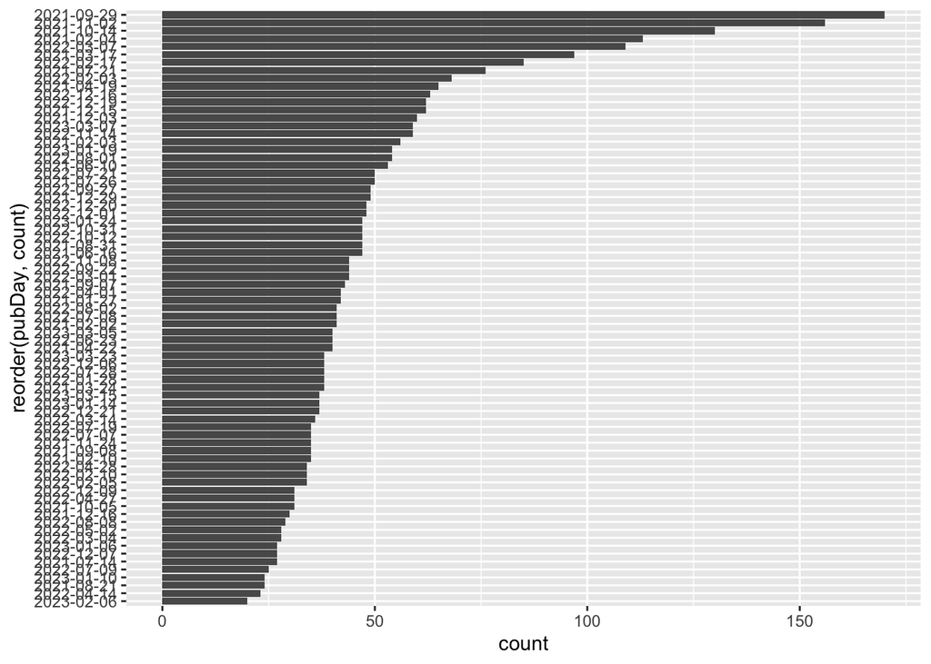

```r
ppd <- tokenized2 %>%
  mutate(pubDay=gsub("T.*","",response.docs.pub_date)) %>%
  filter(response.docs.news_desk %in% c("Climate", "Science")) |>
  group_by(pubDay) %>%
  summarise(count=n()) %>%
  filter(count >= 20) %>%
  ggplot() +
  geom_bar(aes(x=reorder(pubDay, count), y=count), stat="identity") +
  coord_flip()
ppd
```

## Word frequency

```r
data(stop_words)
stop_words
```

```
## # A tibble: 1,149 × 2
##    word        lexicon
##    <chr>       <chr>
##  1 a           SMART
##  2 a's         SMART
##  3 able        SMART
##  4 about       SMART
##  5 above       SMART
##  6 according   SMART
##  7 accordingly SMART
##  8 across      SMART
##  9 actually    SMART
## 10 after       SMART
## # … with 1,139 more rows
```

```r
tokenized2 <- tokenized2 %>%
  anti_join(stop_words)
```

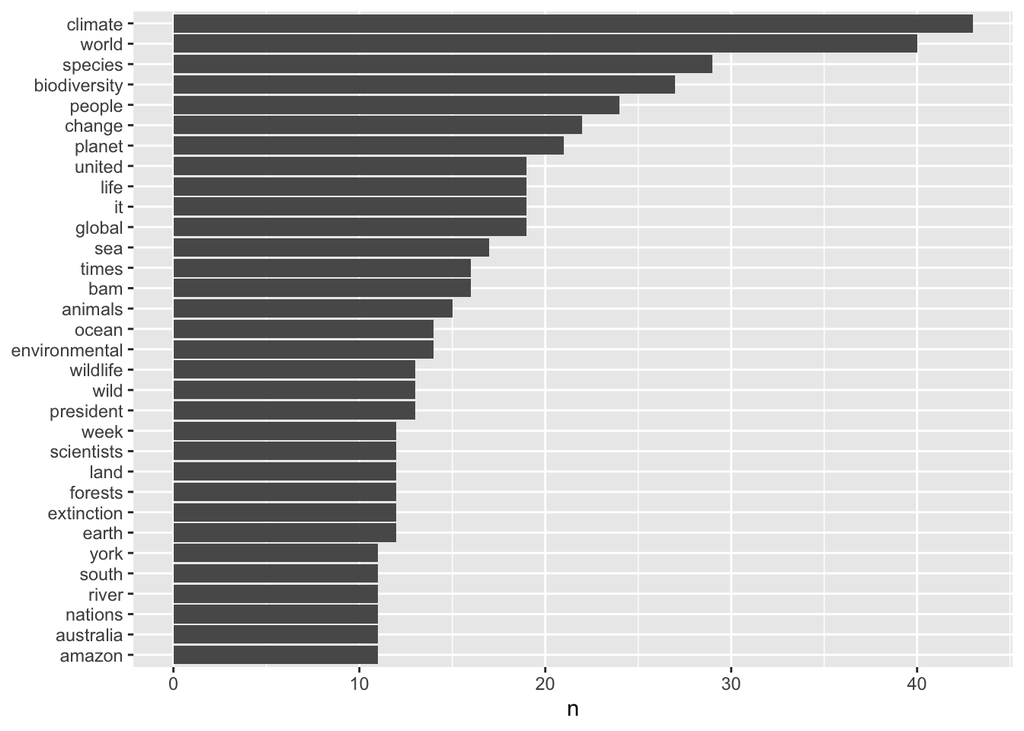

```r
wf <- tokenized2 %>%
  count(clean, sort = TRUE) %>%
  filter(n > 10) %>%
  mutate(clean = reorder(clean, n)) %>%
  ggplot(aes(n, clean)) +
  geom_col() +
  labs(y = NULL)

wf
```

4. Recreate the publications per day and word frequency plots using the headlines variable (response.docs.headline.main). Compare the distributions of word frequencies between the first paragraph and headlines. Do you see any difference?

# Publications per day

```r
headline <- names(nytDat2)[20]
token_headlines <- nytDat2 %>%
unnest_tokens(word, headline)
head(token_headlines[,"word"])
```

```
## [1] "why"     "tiny"    "ponds"   "and"     "singing" "frogs"
```

```r
head(token_headlines$word)
```

```
## [1] "why"     "tiny"    "ponds"   "and"     "singing" "frogs"
```

```r
#remove the empty strings
tib3 <-subset(token_headlines, word!="")
#reassign
token_headlines <- tib3
```

```r
data(stop_words)
stop_words
```

```
## # A tibble: 1,149 × 2
##    word        lexicon
##    <chr>       <chr>
##  1 a           SMART
##  2 a's         SMART
##  3 able        SMART
##  4 about       SMART
##  5 above       SMART
##  6 according   SMART
##  7 accordingly SMART
##  8 across      SMART
##  9 actually    SMART
## 10 after       SMART
## # … with 1,139 more rows
```

```r
token_headlines <- token_headlines %>%
  anti_join(stop_words)
```

```r
ppd2 <- token_headlines %>%
  mutate(pubDay=gsub("T.*","",response.docs.pub_date)) %>%
  filter(response.docs.news_desk %in% c("Climate", "Science")) |>
  group_by(pubDay) %>%
  summarise(count=n()) %>%
  filter(count >= 8) %>%
  ggplot() +
  geom_bar(aes(x=reorder(pubDay, count), y=count), stat="identity") +
  coord_flip()
```

[output not shown]

# Word frequency

```r
#reassign
token_headlines <- tib3
wf2 <- token_headlines %>%
  count(word, sort = TRUE) %>%
  filter(n > 5) %>%
  mutate(word = reorder(word, n)) %>%
  ggplot(aes(n, word)) +
  geom_col() +
  labs(y = NULL)
```

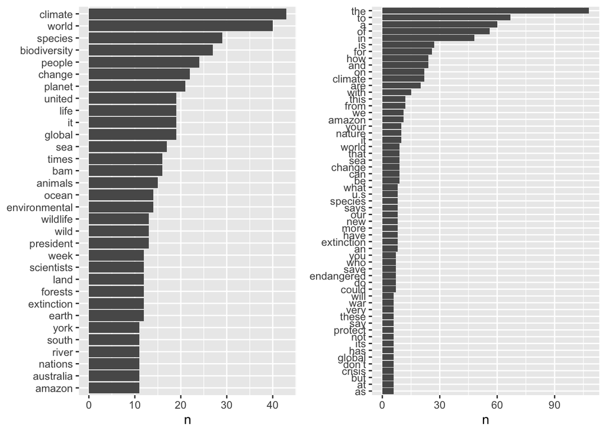

```r
gridExtra::grid.arrange(wf, wf2, ncol=2)
```